# Week 3 Notes Part 3 Non-Parametric Statistical Tests

# 1 Overview

In Parts 1 and 2 of this week’s Notes we built linear models on the assumption that the errors, or in the more flexible models of Part 2 the residuals, are approximately normally distributed. The diagnostic plots we worked through in Part 1, the QQ plot and the Shapiro-Wilk test in particular, exist precisely so that this assumption can be checked rather than simply taken on faith. In this Note we take up the question of what to do when that check fails, or when we have reason to distrust the assumption before we have even fit a model.

The answer, broadly, is to give up some information in exchange for giving up the assumption. A non-parametric test makes no claim about the distribution the data were drawn from; it works instead with the rank order of the observations, meaning the position each value occupies once the data have been sorted from smallest to largest. Because a rank is defined the same way regardless of whether the underlying distribution is normal, exponential, or something with no convenient name at all, a test built on ranks remains valid under any distribution. We pay for this generality with a small loss of power when the parametric assumptions actually do hold, a point we will return to and demonstrate directly toward the end of this Note.

# 2 Why Non-Parametric Tests?

The parametric tests we have used so far, the t-test, ANOVA, Pearson correlation, and linear regression, derive their power from an assumption about how the data are distributed, most commonly that the data themselves, or their residuals, follow a normal distribution. When this assumption holds, a parametric test is the right tool to reach for: it extracts the most information the data have to offer and gives us the most powerful test available for a given sample size.

The assumption does not always hold, however, and biomedical data give us little reason to expect that it will. Gene expression measurements, days to remission, survival times, and a great many other quantities we work with in this course are commonly skewed, heavy-tailed, or shaped by a handful of influential outliers. When that is the case, the sampling distribution of the test statistic we compute may no longer follow the distribution the test assumes, and as a consequence the p-value it returns can no longer be trusted at face value, nor can the parameter estimates that go with it.

Non-parametric tests sidestep the problem by replacing the raw values with their ranks before any further calculation is done. A rank preserves the ordering in the data, that is, which observations are larger and which are smaller than which others, while discarding the specific numerical values themselves. Because the resulting test statistic is built entirely from ranks, its distribution under the null hypothesis does not depend on the distribution the original data came from, which is what we mean when we call these tests distribution-free.

# 3 Spearman Rank Correlation

## 3.1 Concept

Recall from Week 3 Part 1 that Pearson correlation measures the strength of the linear relationship between two variables, and that it does so by assuming both variables are approximately normally distributed; it is also, as a consequence of using raw values rather than ranks, sensitive to outliers.

Spearman’s rank correlation addresses both concerns by first replacing each observation with its rank within its own variable, and then computing the ordinary Pearson correlation of those ranks rather than of the original values. This gives us

$$r_s = 1 - \frac{6\sum
d_i^2}{n(n^2-1)}$$

where $d_i$ is the difference between the two ranks assigned to observation $i$ and $n$ is the sample size. Because it is built from ranks rather than raw values, $r_s$ measures a monotonic relationship rather than a strictly linear one, that is, it asks whether one variable tends to increase as the other increases (or decrease as the other increases), without requiring that this tendency follow a straight line. As with Pearson’s $r$, a value of $r_s$ near $+1$ indicates a nearly perfect increasing relationship, a value near $-1$ indicates a nearly perfect decreasing one, and a value near $0$ indicates no monotonic association at all.

## 3.2 When to Use Spearman vs. Pearson

The choice between the two comes down to what the scatterplot and the diagnostics tell us about the data at hand. We should reach for Spearman when the relationship between the two variables looks nonlinear but still monotonic, when one or both variables are skewed or contain outliers that would otherwise dominate a Pearson calculation, when the variables are ordinal rather than continuous, so that only their order and not their exact spacing is meaningful, or when the normality diagnostics from Part 1, the Shapiro-Wilk test and the QQ plot, have already raised doubts about the data. Pearson, conversely, remains the better choice when the relationship is genuinely linear, as confirmed visually or by the linear model diagnostics from Part 1, when both variables are approximately normally distributed, and when we specifically want the coefficient to carry the least-squares regression interpretation that only Pearson’s $r$ provides.

## 3.3 Example in R

Let us reconstruct the days-to-remission variable exactly as we did in Part 1, and correlate it against the expression of a single gene, comparing the Pearson and Spearman results directly.

```r
library(ALL); data(ALL)
# Reconstruct days-to-remission:
ALL.pdat    <- pData(ALL)
date.cr.chr <- as.character(ALL.pdat$date.cr)
diag.chr    <- as.character(ALL.pdat$diagnosis)
date.cr.t   <- strptime(date.cr.chr, "%m/%d/%Y")
diag.t      <- strptime(diag.chr,    "%m/%d/%Y")
days2remiss <- as.numeric(date.cr.t - diag.t)
gene.names  <- rownames(exprs(ALL))
G <- exprs(ALL)[gene.names[50], ]
complete <- !is.na(days2remiss)
d2r   <- days2remiss[complete]
g.vec <- G[complete]

par(mfrow=c(1,2))
# Scatterplot to visualize the relationship:
plot(g.vec, d2r, pch=16, col="gray60",
     xlab="Gene expression", ylab="Days to remission",
     main="Gene expression vs. D2R")
abline(lm(d2r ~ g.vec), col="red", lwd=2)

# Pearson correlation (parametric):
pearson.result  <- cor.test(g.vec, d2r, method="pearson")
# Spearman correlation (non-parametric):
spearman.result <- cor.test(g.vec, d2r, method="spearman")

cat("Pearson r:", round(pearson.result$estimate, 3),
    "  p =", round(pearson.result$p.value, 4), "\n")
```

```
## Pearson r: 0.071   p = 0.494
```

```r
cat("Spearman rho:", round(spearman.result$estimate, 3),
    "  p =", round(spearman.result$p.value, 4), "\n")
```

```
## Spearman rho: 0.084   p = 0.4147
```

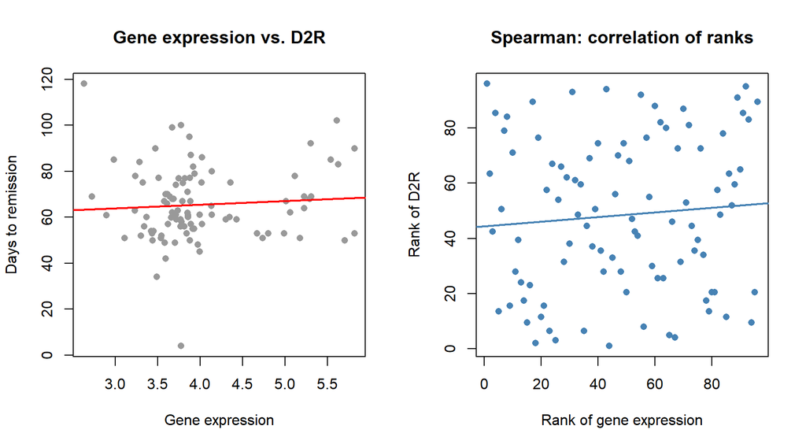

```r
# Visualize the rank transformation:
plot(rank(g.vec), rank(d2r), pch=16, col="steelblue",
     xlab="Rank of gene expression", ylab="Rank of D2R",
     main="Spearman: correlation of ranks")
abline(lm(rank(d2r) ~ rank(g.vec)), col="steelblue", lwd=2)
```

```r
par(mfrow=c(1,1))
```

The panel on the right shows the two variables after they have been converted to ranks, which is the substitution that makes Spearman correlation what it is; the value $r_s$ we printed above is nothing more than the Pearson correlation of these two rank sequences. It is worth comparing the two printed results directly: when the Pearson and Spearman values agree closely, as they do reasonably well here, this is evidence that the relationship between the two variables is close to linear and that the normality assumption behind Pearson’s $r$ is not doing much work. When the two values diverge substantially, that divergence is itself informative, and it usually means the relationship is monotonic but curved, or that an outlier is pulling the Pearson estimate away from the bulk of the data.

## 3.4 Genome-Wide Application

The same logic scales naturally to genomics, where it is common to correlate a single clinical variable, here days-to-remission, against thousands of genes at once. Because a genome-wide screen inevitably turns up genes with skewed or outlier-laden expression, Spearman correlation is often the more defensible default in this setting than Pearson, exactly as the discussion above would predict.

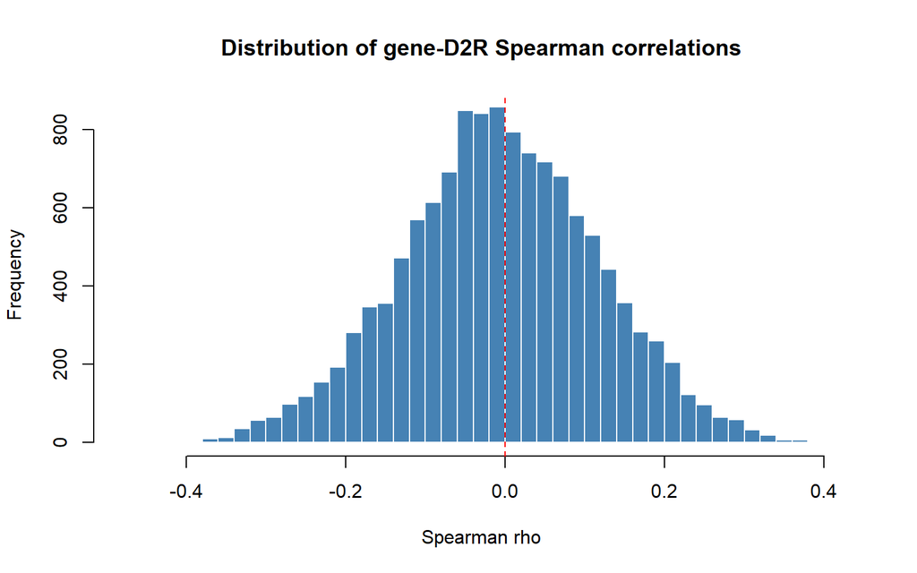

```r
# Spearman correlation of all genes with days-to-remission:
expr.mat <- exprs(ALL)[, complete]
spearman.cors <- apply(expr.mat, 1, function(g) {
  cor(g, d2r, method="spearman", use="complete.obs")
})
# Distribution of Spearman correlations across all genes:
hist(spearman.cors, breaks=50, col="steelblue",
     xlab="Spearman rho", main="Distribution of gene-D2R Spearman correlations",
     border="white")
abline(v=0, lty=2, col="red")
```

```r
cat("Top 5 positively correlated genes:\n")
```

```
## Top 5 positively correlated genes:
```

```r
print(sort(spearman.cors, decreasing=TRUE)[1:5])
```

[output not shown]

```r
cat("\nTop 5 negatively correlated genes:\n")
```

```
##
## Top 5 negatively correlated genes:
```

```r
print(sort(spearman.cors)[1:5])
```

[output not shown]

The histogram gives us a picture of the full distribution of gene-by-gene associations at once, centered, as we would expect under the null hypothesis of no association, near zero, with the genes we singled out at the top and bottom of the printed lists sitting out in the tails as the strongest positive and negative candidates.

# 4 Wilcoxon Rank-Sum Test (Mann-Whitney U Test)

## 4.1 Concept

The two-sample t-test we used in Week 2 Part 3 tests whether the means of two groups differ, and it does so under the assumption that both groups are drawn from approximately normal distributions with a variance that is either equal between the groups or estimated separately. The Wilcoxon rank-sum test, also known as the Mann-Whitney U test, is the non-parametric alternative to this procedure: rather than comparing means, it asks whether observations from one group tend to be systematically larger or smaller than observations from the other, and it does so without assuming anything about the shape of either group’s distribution.

The mechanics of the test follow the same pattern we saw with Spearman correlation. All of the observations from both groups are pooled together and ranked from smallest to largest, and the test then asks whether the ranks that ended up in one group are systematically higher or lower than the ranks that ended up in the other. Under the null hypothesis that both groups were drawn from the same distribution, we would expect the ranks to be interleaved roughly evenly between the two groups, with neither group’s ranks clustering toward one end.

## 4.2 When to Use Wilcoxon vs. t-test

As with Spearman and Pearson, the choice between Wilcoxon and the t-test follows from what we know, or suspect, about the data. Wilcoxon is the safer choice when the data within one or both groups are skewed rather than approximately normal, when the sample sizes are small enough that we cannot lean on the Central Limit Theorem to rescue the t-statistic’s normality, when a small number of outliers would otherwise have undue influence on a group’s mean, or when the outcome itself is ordinal, such as a severity rating rather than a continuous measurement. The t-test remains the better choice when both groups are approximately normally distributed, a claim we can check directly with the Shapiro-Wilk test or a QQ plot as we did in Part 1, when the sample sizes are large enough for the CLT to make the t-statistic’s normality a safe approximation regardless of the underlying data, and when what we specifically want to test is a difference in means rather than a more general shift in distribution.

## 4.3 Example in R

Let us compare gene expression between relapsed and non-relapsed patients, first checking normality within each group directly, and then running the t-test and the Wilcoxon test side by side.

```r
library(ALL); data(ALL)
# Compare gene expression levels between relapsed and non-relapsed patients:
b.mask     <- !is.na(pData(ALL)$relapse)
relapse    <- pData(ALL)$relapse[b.mask]
gene.expr  <- exprs(ALL)[gene.names[50], b.mask]

# Check normality within each group:
cat("Shapiro-Wilk test within relapsed group:\n")
```

```
## Shapiro-Wilk test within relapsed group:
```

```r
print(shapiro.test(gene.expr[relapse]))
```

```
##
##  Shapiro-Wilk normality test
##
## data:  gene.expr[relapse]
## W = 0.852, p-value = 1.625e-06
```

```r
cat("\nShapiro-Wilk test within non-relapsed group:\n")
```

```
##
## Shapiro-Wilk test within non-relapsed group:
```

```r
print(shapiro.test(gene.expr[!relapse]))
```

```
##
##  Shapiro-Wilk normality test
##
## data:  gene.expr[!relapse]
## W = 0.89102, p-value = 0.002289
```

```r
par(mfrow=c(1,2))
# Visualize distributions:
boxplot(gene.expr ~ relapse,
        names=c("No relapse","Relapse"),
        col=c("steelblue","tomato"),
        ylab="Gene expression",
        main="Gene expression by relapse status")

# t-test (parametric):
t.result <- t.test(gene.expr[relapse], gene.expr[!relapse])
# Wilcoxon rank-sum test (non-parametric):
w.result <- wilcox.test(gene.expr[relapse], gene.expr[!relapse])

cat("\nt-test:         p =", round(t.result$p.value, 4), "\n")
```

```
##
## t-test:         p = 0.7189
```

```r
cat("Wilcoxon test:  p =", round(w.result$p.value, 4), "\n")
```

```
## Wilcoxon test:  p = 0.9712
```

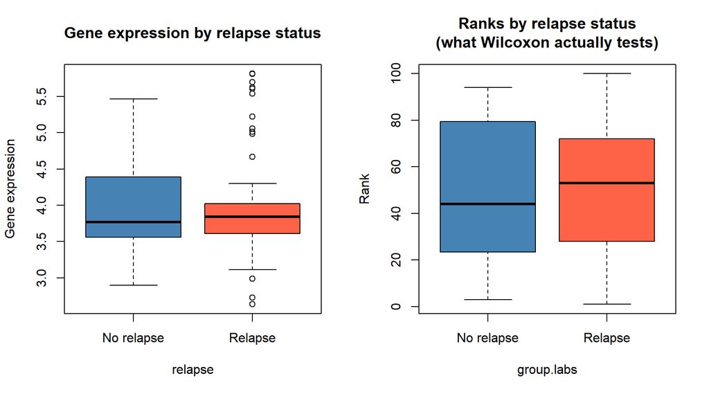

```r
# Visualize the rank logic:
all.expr   <- c(gene.expr[relapse], gene.expr[!relapse])
group.labs <- c(rep("Relapse", sum(relapse)), rep("No relapse", sum(!relapse)))
all.ranks  <- rank(all.expr)
boxplot(all.ranks ~ group.labs,
        col=c("steelblue","tomato"),
        ylab="Rank",
        main="Ranks by relapse status\n(what Wilcoxon actually tests)")
```

```r
par(mfrow=c(1,1))
```

The panel on the right shows the ranks rather than the raw expression values, which is what the Wilcoxon test is actually working with; when the two groups genuinely differ, one group’s ranks will sit systematically higher than the other’s, exactly the pattern we would look for in this plot. As with the Spearman versus Pearson comparison above, agreement between the t-test and Wilcoxon p-values here is reassuring: it tells us the normality assumption was not doing much work for these particular data. Where the two disagree substantially, we should generally trust the Wilcoxon result over the t-test’s.

## 4.4 Wilcoxon Signed-Rank Test (Paired Data)

The rank-sum test above is built for two independent groups, but a great deal of biomedical data is paired rather than independent, the same patient measured before and after treatment, or the same tissue sample assayed under two conditions. For data of this kind, the Wilcoxon signed-rank test is the non-parametric analog of the paired t-test, and it works by ranking the absolute values of the within-pair differences rather than the raw observations themselves.

```r
# Simulate paired pre/post-treatment gene expression:
set.seed(42)
n.paired <- 30
pre.treatment  <- rnorm(n.paired, mean=8, sd=1.5)
# Treatment reduces expression on average, but with some skew:
post.treatment <- pre.treatment - 0.8 + rexp(n.paired, rate=2) - 0.5
# Paired t-test:
paired.t <- t.test(post.treatment, pre.treatment, paired=TRUE)
# Wilcoxon signed-rank test:
paired.w <- wilcox.test(post.treatment, pre.treatment, paired=TRUE)
cat("Paired t-test p:", round(paired.t$p.value, 4), "\n")
```

```
## Paired t-test p: 9e-04
```

```r
cat("Wilcoxon signed-rank p:", round(paired.w$p.value, 4), "\n")
```

```
## Wilcoxon signed-rank p: 4e-04
```

We built a small amount of skew into the simulated post-treatment values on purpose, by way of the exponential term added to each difference, so that this example would give the two tests a genuine opportunity to disagree, in the same spirit as the two-group comparison above.

# 5 Kruskal-Wallis Test

## 5.1 Concept

One-way ANOVA, which we will take up formally in Week 5 Part 1, tests whether the means of three or more groups differ, under the assumption of normally distributed residuals within each group. The Kruskal-Wallis test extends the logic of the Wilcoxon rank-sum test to more than two groups in the same way that ANOVA extends the logic of the t-test: it asks whether observations from any one of $k$ groups tend to be systematically larger or smaller than the others, without assuming normality anywhere in the calculation.

The mechanics follow the pattern we have now seen twice. All observations across all $k$ groups are pooled and ranked, and the test asks whether the mean rank differs across groups by more than we would expect from chance alone. Under the null hypothesis that all groups are drawn from the same distribution, the mean rank within each group should come out approximately equal. The resulting Kruskal-Wallis statistic, conventionally written $H$, follows approximately a chi-square distribution with $k-1$ degrees of freedom, where $k$ is the number of groups being compared, and it is from this chi-square approximation that the test’s p-value is obtained.

## 5.2 Post-Hoc Testing

As with ANOVA, a significant Kruskal-Wallis result only tells us that at least one group differs from the others somewhere; it does not tell us which group or groups are responsible. The standard non-parametric answer to this question is the Dunn test, or equivalently a set of pairwise Wilcoxon rank-sum tests with a multiple-testing correction applied across them, playing the same role here that Tukey’s HSD plays after a significant ANOVA.

## 5.3 Example in R

Let us compare gene expression across the BT subtypes recorded in the ALL dataset’s phenotype data, a natural setting for Kruskal-Wallis since there are more than two groups to compare at once.

```r
library(ALL); data(ALL)
# Compare gene expression across BT subtypes (multiple groups):
bt.type   <- pData(ALL)$BT
gene.expr2 <- exprs(ALL)[gene.names[50], ]

# Remove small/rare subtypes for clarity:
bt.counts <- table(bt.type)
common.bt <- names(bt.counts[bt.counts >= 10])
mask.bt   <- bt.type %in% common.bt
bt.sub    <- factor(bt.type[mask.bt])
ge.sub    <- gene.expr2[mask.bt]

par(mfrow=c(1,2))
# Visualize:
boxplot(ge.sub ~ bt.sub,
        col=rainbow(nlevels(bt.sub)),
        xlab="BT subtype", ylab="Gene expression",
        main="Expression by BT subtype",
        las=2, cex.axis=0.8)

# One-way ANOVA (parametric):
anova.result <- summary(aov(ge.sub ~ bt.sub))
cat("One-way ANOVA p:", round(anova.result[[1]]$`Pr(>F)`[1], 4), "\n")
```

```
## One-way ANOVA p: 0.0563
```

```r
# Kruskal-Wallis test (non-parametric):
kw.result <- kruskal.test(ge.sub ~ bt.sub)
cat("Kruskal-Wallis p:", round(kw.result$p.value, 4), "\n")
```

```
## Kruskal-Wallis p: 0.0879
```

```r
print(kw.result)
```

```
##
##  Kruskal-Wallis rank sum test
##
## data:  ge.sub by bt.sub
## Kruskal-Wallis chi-squared = 9.5847, df = 5, p-value = 0.08789
```

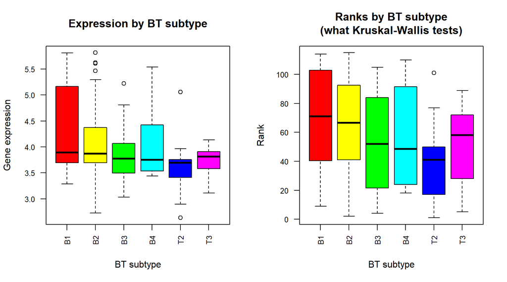

```r
# Visualize ranks by group:
ge.ranks <- rank(ge.sub)
boxplot(ge.ranks ~ bt.sub,
        col=rainbow(nlevels(bt.sub)),
        xlab="BT subtype", ylab="Rank",
        main="Ranks by BT subtype\n(what Kruskal-Wallis tests)",
        las=2, cex.axis=0.8)
```

```r
par(mfrow=c(1,1))
```

```r
# Post-hoc pairwise Wilcoxon tests with BH correction:
pairwise.result <- pairwise.wilcox.test(ge.sub, bt.sub,
                                         p.adjust.method="BH")
cat("\nPairwise Wilcoxon (BH-adjusted p-values):\n")
```

```
##
## Pairwise Wilcoxon (BH-adjusted p-values):
```

```r
print(round(pairwise.result$p.value, 3))
```

```
##       B1    B2    B3    B4    T2
## B2 0.743    NA    NA    NA    NA
## B3 0.481 0.481    NA    NA    NA
## B4 0.593 0.593 0.743    NA    NA
## T2 0.093 0.093 0.481 0.499    NA
## T3 0.481 0.481 0.893 0.743 0.489
```

# 6 Comparing Parametric and Non-Parametric Tests: A Simulation

We have asserted twice now that non-parametric tests trade some power for robustness, and rather than leave that claim unexamined, let us build a small simulation that lets us see it directly, comparing the power of the t-test against the Wilcoxon test under both normal and non-normal data.

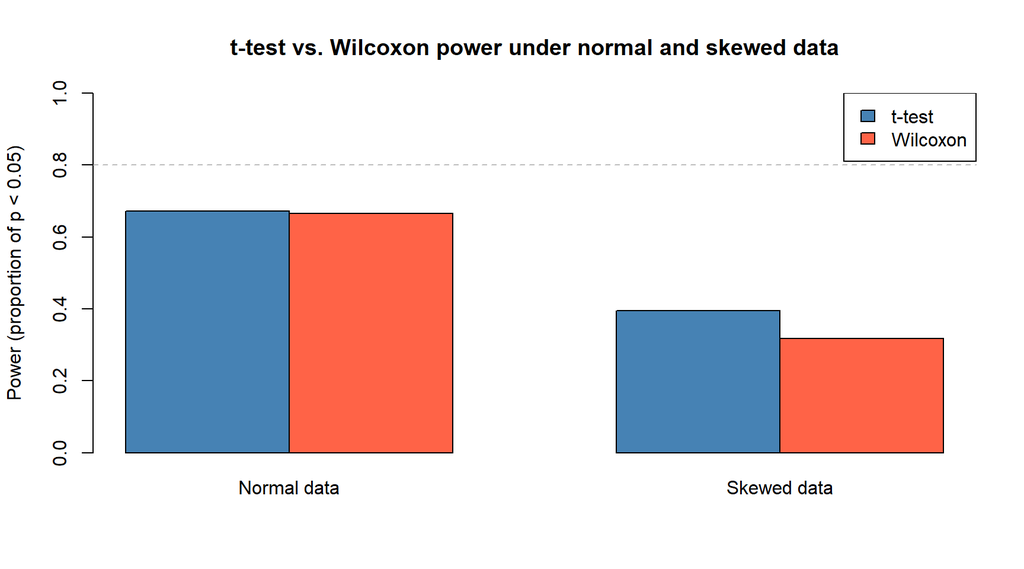

```r
set.seed(99)
n.sim   <- 1000
n.samp  <- 20      # small sample size (common in genomics)
delta   <- 0.8     # true effect size

# Simulation 1: Normal data -- compare power
power.t.normal <- mean(replicate(n.sim, {
  g1 <- rnorm(n.samp, 0, 1)
  g2 <- rnorm(n.samp, delta, 1)
  t.test(g1, g2)$p.value < 0.05
}))
power.w.normal <- mean(replicate(n.sim, {
  g1 <- rnorm(n.samp, 0, 1)
  g2 <- rnorm(n.samp, delta, 1)
  wilcox.test(g1, g2)$p.value < 0.05
}))

# Simulation 2: Skewed data (exponential) -- compare power
power.t.skewed <- mean(replicate(n.sim, {
  g1 <- rexp(n.samp, 1)
  g2 <- rexp(n.samp, 1/(1+delta))
  t.test(g1, g2)$p.value < 0.05
}))
power.w.skewed <- mean(replicate(n.sim, {
  g1 <- rexp(n.samp, 1)
  g2 <- rexp(n.samp, 1/(1+delta))
  wilcox.test(g1, g2)$p.value < 0.05
}))

results.df <- data.frame(
  Data       = c("Normal", "Normal", "Skewed", "Skewed"),
  Test       = c("t-test", "Wilcoxon", "t-test", "Wilcoxon"),
  Power      = c(power.t.normal, power.w.normal,
                 power.t.skewed, power.w.skewed)
)
barplot(matrix(results.df$Power, nrow=2),
        beside=TRUE,
        names.arg=c("Normal data", "Skewed data"),
        col=c("steelblue","tomato"),
        ylab="Power (proportion of p < 0.05)",
        main="t-test vs. Wilcoxon power under normal and skewed data",
        ylim=c(0,1))
legend("topright", c("t-test","Wilcoxon"), fill=c("steelblue","tomato"))
abline(h=0.8, lty=2, col="gray")
```

```r
print(results.df)
```

```
##     Data     Test Power
## 1 Normal   t-test 0.672
## 2 Normal Wilcoxon 0.666
## 3 Skewed   t-test 0.395
## 4 Skewed Wilcoxon 0.317
```

# 7 Summary: Parametric vs. Non-Parametric Tests

Let us draw the correspondences of this Note together in one place. Pearson correlation has Spearman correlation as its non-parametric counterpart, relaxing the assumption of linearity and of normality in both variables. The two-sample t-test has the Wilcoxon rank-sum test, or Mann-Whitney U test, as its counterpart, relaxing the assumption of normality within each group, and the paired t-test has the Wilcoxon signed-rank test as its counterpart, relaxing the assumption of normality in the paired differences. One-way ANOVA has the Kruskal-Wallis test as its counterpart, relaxing the assumption of normality of the residuals within groups, and Tukey’s HSD post-hoc procedure has the BH-corrected pairwise Wilcoxon tests as its counterpart, relaxing that same assumption in the post-hoc setting. Finally, linear regression itself has LOESS, splines, and generalized additive models as its non-parametric counterparts, relaxing the assumption of linearity as well as normality of the residuals, and these are treated in full in Week 3 Part 2.

In practice, the workflow we recommend is to fit the parametric test first, since it is generally more powerful when its assumptions hold, and then to run the diagnostic checks from Part 1, the Shapiro-Wilk test, the QQ plot, and a look at residuals against fitted values, before trusting its p-value. If normality is clearly violated, particularly with a small sample size, we should switch to the corresponding non-parametric test. When the parametric and non-parametric results agree closely, that agreement is itself reassuring evidence that the distributional assumption was not critical to the conclusion; when they disagree substantially, the non-parametric result is ordinarily the one to trust.